# Pertemuan 5 - Kestasioneran Data

G1401211043_Yogi Nur Hamid

2023-09-30

```r
library(ggplot2)
library(tsibble)
library(tseries)
library(MASS)
```

# Data

## Impor data

```r
data <- rio::import("https://raw.githubusercontent.com/yoginurhamid/MPDW/main/Pertemuan%205/Data%20Prak%201.csv")
data
```

```
##          Date Jumlah penumpang KRL Jabodetabek (Ribu jiwa)
## 1    1/1/2006                                         8681
## 2    2/1/2006                                         8144
## 3    3/1/2006                                         8920
## 4    4/1/2006                                         8462
## 5    5/1/2006                                         8899
## 6    6/1/2006                                         8606
## 7    7/1/2006                                         8787
## 8    8/1/2006                                         8661
## 9    9/1/2006                                         8829
## 10  10/1/2006                                         8767
## 11  11/1/2006                                         8895
## 12  12/1/2006                                         8774
## 13   1/1/2007                                         8723
## 14   2/1/2007                                         7566
```

[output cut: 196 more lines]

## Merapihkan data

```r
#Membuat data frame baru dengan kolom periode
data1 <- cbind.data.frame(seq(1,210),data$`Jumlah penumpang KRL Jabodetabek (Ribu jiwa)`)

#Mengganti nama kolom
colnames(data1)[1] <- "Periode"
colnames(data1)[2] <- "Penumpang"

data
```

```
##          Date Jumlah penumpang KRL Jabodetabek (Ribu jiwa)
## 1    1/1/2006                                         8681
## 2    2/1/2006                                         8144
## 3    3/1/2006                                         8920
## 4    4/1/2006                                         8462
## 5    5/1/2006                                         8899
## 6    6/1/2006                                         8606
## 7    7/1/2006                                         8787
## 8    8/1/2006                                         8661
## 9    9/1/2006                                         8829
## 10  10/1/2006                                         8767
## 11  11/1/2006                                         8895
## 12  12/1/2006                                         8774
## 13   1/1/2007                                         8723
## 14   2/1/2007                                         7566
```

[output cut: 196 more lines]

# Kestasioneran Data

## Eksplorasi data

Identifikasi variabel

```r
Periode <- data1$Periode
Penumpang <- data1$Penumpang
```

Membuat data time series

```r
stas <- ts(data1$Penumpang)
```

```r
mean(stas)
```

```
## [1] 16127.94
```

## Plot time series

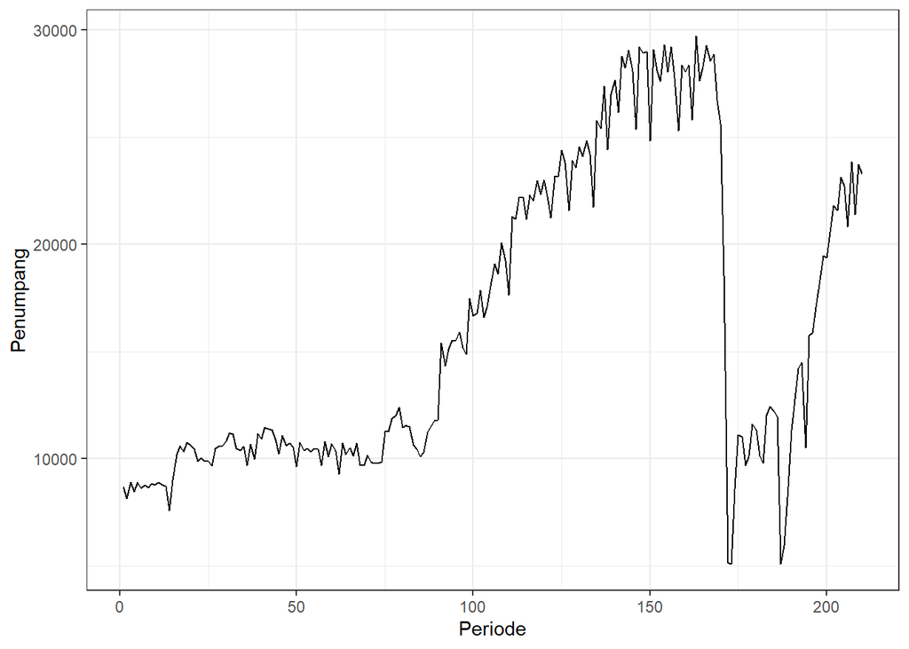

```r
plot_ts <- stas |> as_tsibble() |>
  ggplot(aes(x = Periode, y = Penumpang)) + geom_line() + theme_bw() +
  xlab("Periode") + ylab("Penumpang")
plot_ts
```

Berdasarkan plot deret waktu, terlihat bahwa data tidak stasioner dalam rataan maupun ragam.

## Plot ACF

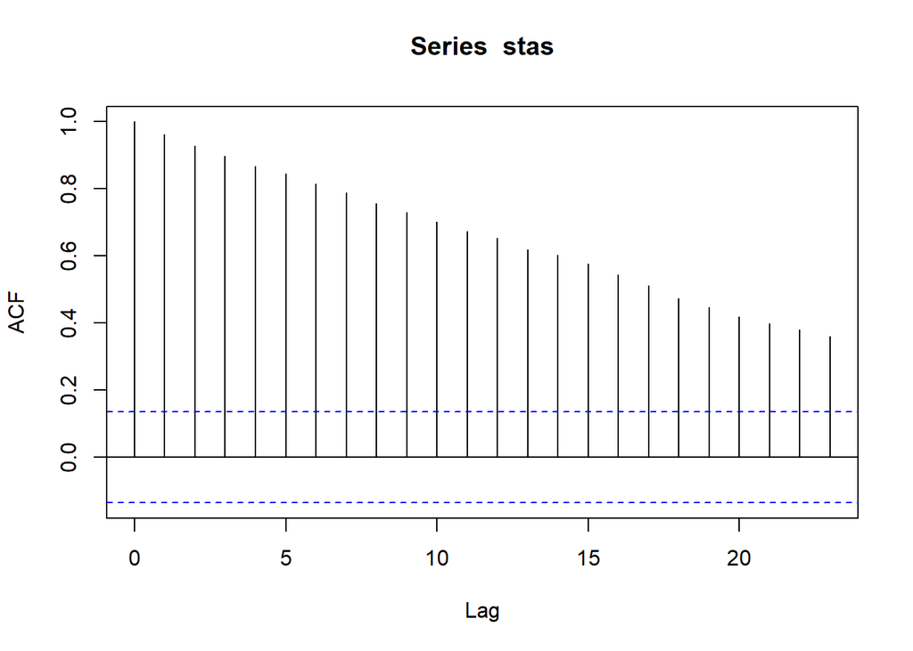

```r
acf(stas)
```

Berdasarkan plot ACF, terlihat bahwa data cenderung *tails off* yang mengartikan bahwa data tidak stasioner.

## Uji ADF

$H_0$ : Data tidak stasioner dalam rataan

$H_1$ : Data stasioner dalam rataan

```r
tseries::adf.test(stas)
```

```
##
##  Augmented Dickey-Fuller Test
##
## data:  stas
## Dickey-Fuller = -2.0517, Lag order = 5, p-value = 0.5544
## alternative hypothesis: stationary
```

Diperoleh *p-value* sebesar 0.5544 > 0.05 sehingga Tak Tolak $H_0$. Artinya, belum cukup bukti untuk menyatakan bahwa data stasioner dalam rataan. Pernyataan tersebut terbukti sama dengan grafik yang ditunjukkan oleh plot time series dan plot ACF.

## Plot Box-Cox

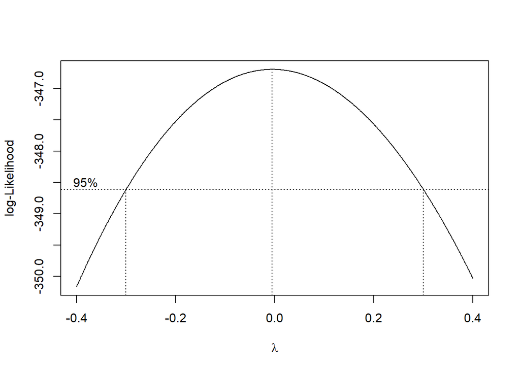

```r
#Menentukan n = banyak data jumlah penumpang
n <- length(stas)

#Membuat plot
index <- seq(1:n)

bc <- boxcox(stas~index, lambda = seq(-0.4,0.4,by=0.001))
```

```r
#Nilai Rounded Lambda
lambda <- bc$x[which.max(bc$y)]
lambda
```

```
## [1] -0.005
```

```r
#SK
bc$x[bc$y > max(bc$y) - 1/2 * qchisq(.95,1)]
```

```
##   [1] -0.300 -0.299 -0.298 -0.297 -0.296 -0.295 -0.294 -0.293 -0.292 -0.291
##  [11] -0.290 -0.289 -0.288 -0.287 -0.286 -0.285 -0.284 -0.283 -0.282 -0.281
##  [21] -0.280 -0.279 -0.278 -0.277 -0.276 -0.275 -0.274 -0.273 -0.272 -0.271
##  [31] -0.270 -0.269 -0.268 -0.267 -0.266 -0.265 -0.264 -0.263 -0.262 -0.261
##  [41] -0.260 -0.259 -0.258 -0.257 -0.256 -0.255 -0.254 -0.253 -0.252 -0.251
##  [51] -0.250 -0.249 -0.248 -0.247 -0.246 -0.245 -0.244 -0.243 -0.242 -0.241
##  [61] -0.240 -0.239 -0.238 -0.237 -0.236 -0.235 -0.234 -0.233 -0.232 -0.231
##  [71] -0.230 -0.229 -0.228 -0.227 -0.226 -0.225 -0.224 -0.223 -0.222 -0.221
##  [81] -0.220 -0.219 -0.218 -0.217 -0.216 -0.215 -0.214 -0.213 -0.212 -0.211
##  [91] -0.210 -0.209 -0.208 -0.207 -0.206 -0.205 -0.204 -0.203 -0.202 -0.201
## [101] -0.200 -0.199 -0.198 -0.197 -0.196 -0.195 -0.194 -0.193 -0.192 -0.191
## [111] -0.190 -0.189 -0.188 -0.187 -0.186 -0.185 -0.184 -0.183 -0.182 -0.181
## [121] -0.180 -0.179 -0.178 -0.177 -0.176 -0.175 -0.174 -0.173 -0.172 -0.171
## [131] -0.170 -0.169 -0.168 -0.167 -0.166 -0.165 -0.164 -0.163 -0.162 -0.161
## [141] -0.160 -0.159 -0.158 -0.157 -0.156 -0.155 -0.154 -0.153 -0.152 -0.151
```

[output cut: 46 more lines]

Berdasarkan plot box-cox, nilai rounded value ($\lambda$) optimum sebesar -0.005 dan pada selang kepercayaan 95% nilai memiliki batas bawah -0.300 dan batas atas 0.300. Selang tersebut tidak memuat nilai satu sehingga dapat dikatakan bahwa data jumlah penumpang KRL tidak stasioner dalam ragam.

# Partisi Data

## Bagian 1

```r
dt_stas1 <- stas[1:70] |> ts()
mean(dt_stas1)
```

```
## [1] 10060.9
```

```r
var(dt_stas1)
```

```
## [1] 766302.1
```

### Plot time series

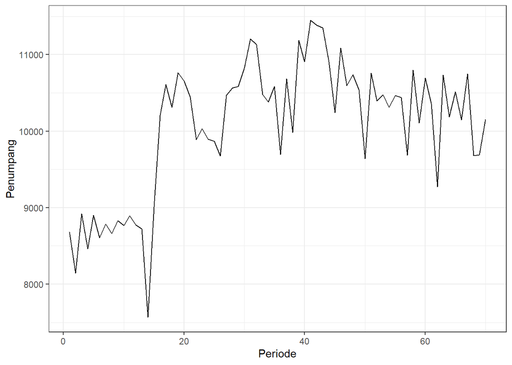

```r
dt_stas1 |> as_tsibble() |>
  ggplot(aes(x = index, y = value)) +
  geom_line() + theme_bw() +
  xlab("Periode") + ylab("Penumpang")
```

Berdasarkan plot deret waktu, terlihat bahwa data tidak stasioner dalam rataan, ditandai dengan data yang tidak menyebar di sekitar nilai tengah. Namun, belum pasti data tidak stasioner dalam ragam.

### Plot ACF

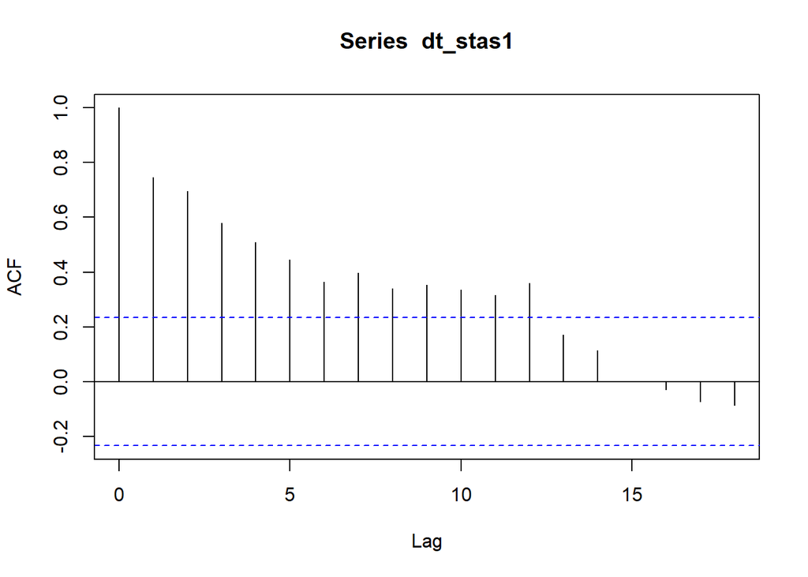

```r
acf(dt_stas1)
```

Berdasarkan plot ACF, terlihat bahwa data hasil partisi yang pertama cenderung *tails off* yang mengartikan bahwa data tidak stasioner dalam rataan.

### Uji ADF

$H_0$ : Data tidak stasioner dalam rataan

$H_1$ : Data stasioner dalam rataan

```r
tseries::adf.test(dt_stas1)
```

```
##
##  Augmented Dickey-Fuller Test
##
## data:  dt_stas1
## Dickey-Fuller = -1.9576, Lag order = 4, p-value = 0.5925
## alternative hypothesis: stationary
```

Diperoleh *p-value* sebesar 0.5924 > 0.05 sehingga Tak Tolak $H_0$. Artinya, belum cukup bukti untuk menyatakan bahwa data stasioner dalam rataan. Pernyataan tersebut terbukti sama dengan grafik yang ditunjukkan oleh plot time series dan plot ACF.

### Plot Box-Cox

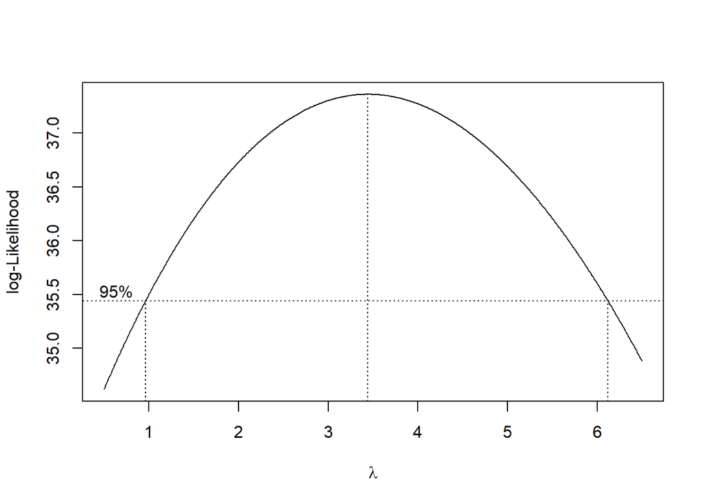

```r
index <- seq(1:70)
bc = boxcox(dt_stas1~index, lambda = seq(0.5,6.5,by=0.01))
```

```r
#Nilai Rounded Lambda
lambda <- bc$x[which.max(bc$y)]
lambda
```

```
## [1] 3.44
```

```r
#SK
bc$x[bc$y > max(bc$y) - 1/2 * qchisq(.95,1)]
```

```
##   [1] 0.97 0.98 0.99 1.00 1.01 1.02 1.03 1.04 1.05 1.06 1.07 1.08 1.09 1.10 1.11
##  [16] 1.12 1.13 1.14 1.15 1.16 1.17 1.18 1.19 1.20 1.21 1.22 1.23 1.24 1.25 1.26
##  [31] 1.27 1.28 1.29 1.30 1.31 1.32 1.33 1.34 1.35 1.36 1.37 1.38 1.39 1.40 1.41
##  [46] 1.42 1.43 1.44 1.45 1.46 1.47 1.48 1.49 1.50 1.51 1.52 1.53 1.54 1.55 1.56
##  [61] 1.57 1.58 1.59 1.60 1.61 1.62 1.63 1.64 1.65 1.66 1.67 1.68 1.69 1.70 1.71
##  [76] 1.72 1.73 1.74 1.75 1.76 1.77 1.78 1.79 1.80 1.81 1.82 1.83 1.84 1.85 1.86
##  [91] 1.87 1.88 1.89 1.90 1.91 1.92 1.93 1.94 1.95 1.96 1.97 1.98 1.99 2.00 2.01
## [106] 2.02 2.03 2.04 2.05 2.06 2.07 2.08 2.09 2.10 2.11 2.12 2.13 2.14 2.15 2.16
## [121] 2.17 2.18 2.19 2.20 2.21 2.22 2.23 2.24 2.25 2.26 2.27 2.28 2.29 2.30 2.31
## [136] 2.32 2.33 2.34 2.35 2.36 2.37 2.38 2.39 2.40 2.41 2.42 2.43 2.44 2.45 2.46
## [151] 2.47 2.48 2.49 2.50 2.51 2.52 2.53 2.54 2.55 2.56 2.57 2.58 2.59 2.60 2.61
## [166] 2.62 2.63 2.64 2.65 2.66 2.67 2.68 2.69 2.70 2.71 2.72 2.73 2.74 2.75 2.76
## [181] 2.77 2.78 2.79 2.80 2.81 2.82 2.83 2.84 2.85 2.86 2.87 2.88 2.89 2.90 2.91
## [196] 2.92 2.93 2.94 2.95 2.96 2.97 2.98 2.99 3.00 3.01 3.02 3.03 3.04 3.05 3.06
## [211] 3.07 3.08 3.09 3.10 3.11 3.12 3.13 3.14 3.15 3.16 3.17 3.18 3.19 3.20 3.21
```

[output cut: 20 more lines]

Berdasarkan plot box-cox, nilai rounded value ($\lambda$) optimum sebesar 3.44 dan pada selang kepercayaan 95% nilai memiliki batas bawah 0.97 dan batas atas 6.12. Selang tersebut memuat nilai satu sehingga dapat dikatakan bahwa data jumlah penumpang KRL stasioner dalam ragam.

## Bagian 2

```r
dt_stas2 <- stas[1:140] |> ts()
mean(dt_stas2)
```

```
## [1] 14047.89
```

```r
var(dt_stas2)
```

```
## [1] 31272411
```

### Plot time series

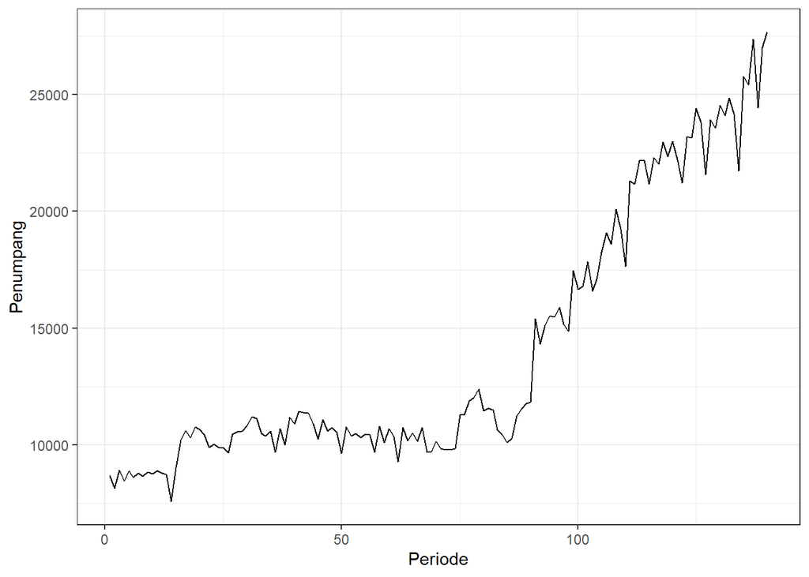

```r
dt_stas2 |> as_tsibble() |>
  ggplot(aes(x = index, y = value)) +
  geom_line() + theme_bw() +
  xlab("Periode") + ylab("Penumpang")
```

Berdasarkan plot deret waktu, terlihat bahwa data tidak stasioner dalam rataan dan ragam, ditandai dengan data yang tidak menyebar di sekitar nilai tengah dan lebar pita yang cenderung berbeda.

### Plot ACF

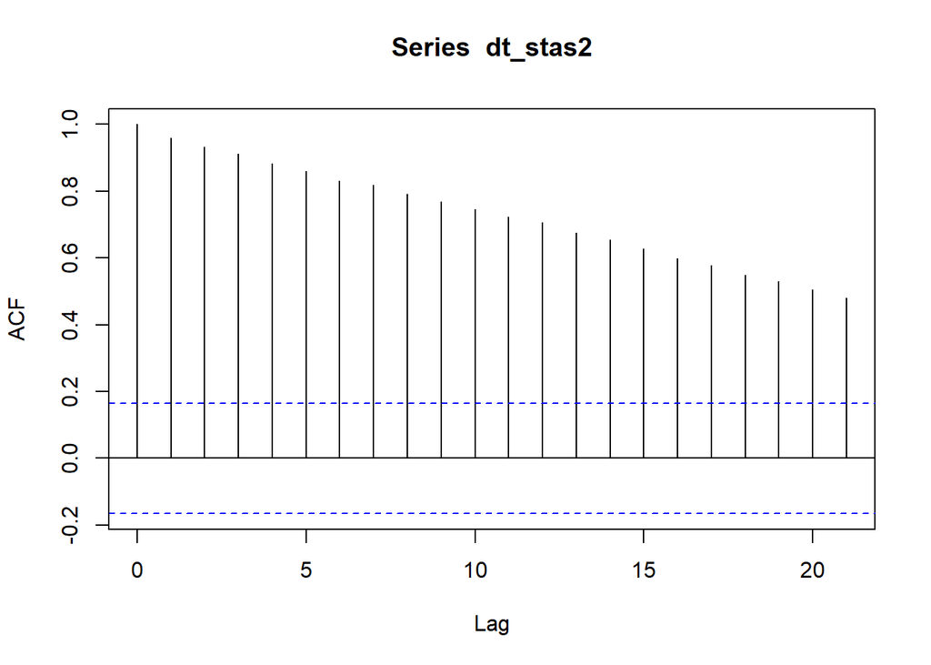

```r
acf(dt_stas2)
```

Berdasarkan plot ACF, terlihat bahwa data hasil partisi yang kedua cenderung *tails off* yang mengartikan bahwa data tidak stasioner dalam rataan.

### Uji ADF

$H_0$ : Data tidak stasioner dalam rataan

$H_1$ : Data stasioner dalam rataan

```r
adf.test(dt_stas2)
```

```
##
##  Augmented Dickey-Fuller Test
##
## data:  dt_stas2
## Dickey-Fuller = -0.56079, Lag order = 5, p-value = 0.9779
## alternative hypothesis: stationary
```

Diperoleh *p-value* sebesar 0.9779 > 0.05 sehingga Tak Tolak $H_0$. Artinya, belum cukup bukti untuk menyatakan bahwa data stasioner dalam rataan. Pernyataan tersebut terbukti sama dengan grafik yang ditunjukkan oleh plot time series dan plot ACF.

### Plot Box-Cox

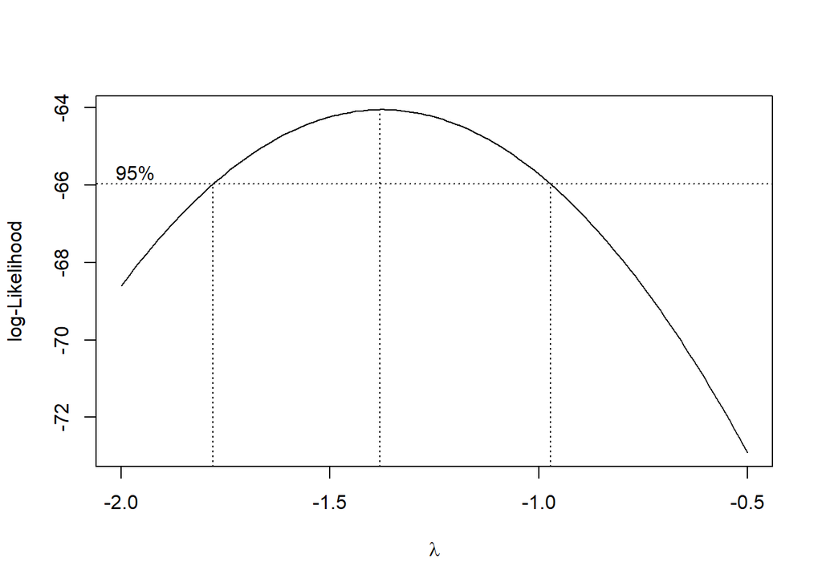

```r
index <- seq(1:140)
bc = boxcox(dt_stas2~index, lambda = seq(-2,-0.5,by=0.01))
```

```r
#Nilai Rounded Lambda
lambda <- bc$x[which.max(bc$y)]
lambda
```

```
## [1] -1.38
```

```r
#SK
bc$x[bc$y > max(bc$y) - 1/2 * qchisq(.95,1)]
```

```
##  [1] -1.77 -1.76 -1.75 -1.74 -1.73 -1.72 -1.71 -1.70 -1.69 -1.68 -1.67 -1.66
## [13] -1.65 -1.64 -1.63 -1.62 -1.61 -1.60 -1.59 -1.58 -1.57 -1.56 -1.55 -1.54
## [25] -1.53 -1.52 -1.51 -1.50 -1.49 -1.48 -1.47 -1.46 -1.45 -1.44 -1.43 -1.42
## [37] -1.41 -1.40 -1.39 -1.38 -1.37 -1.36 -1.35 -1.34 -1.33 -1.32 -1.31 -1.30
## [49] -1.29 -1.28 -1.27 -1.26 -1.25 -1.24 -1.23 -1.22 -1.21 -1.20 -1.19 -1.18
## [61] -1.17 -1.16 -1.15 -1.14 -1.13 -1.12 -1.11 -1.10 -1.09 -1.08 -1.07 -1.06
## [73] -1.05 -1.04 -1.03 -1.02 -1.01 -1.00 -0.99 -0.98
```

Berdasarkan plot box-cox, nilai rounded value ($\lambda$) optimum sebesar -1.38 dan pada selang kepercayaan 95% nilai memiliki batas bawah -1.77 dan batas atas -0.98. Selang tersebut tidak memuat nilai satu sehingga dapat dikatakan bahwa data jumlah penumpang KRL tidak stasioner dalam ragam.